# Assignment 1

I started by importing the libraries I needed for this project and loading the dataset.

```python
import pandas as pd
import numpy as np
import matplotlib.pyplot as plt
import seaborn as sns

from sklearn.model_selection import train_test_split
from sklearn.tree import DecisionTreeClassifier, plot_tree
from sklearn.metrics import (accuracy_score, precision_score, recall_score,
                             f1_score, classification_report,
                             ConfusionMatrixDisplay)
```

I downloaded the dataset as a zip file from Kaggle. The code below uploads it in Google Colab, extracts the CSV, and reads it into a dataframe.

```python
from google.colab import files
import zipfile, io

uploaded = files.upload()
filename = list(uploaded.keys())[0]

if filename.endswith('.zip'):
    with zipfile.ZipFile(io.BytesIO(uploaded[filename]), 'r') as z:
        csv_files = [f for f in z.namelist() if f.endswith('.csv')]
        with z.open(csv_files[0]) as csv_file:
            df = pd.read_csv(csv_file, encoding='latin-1')
else:
    df = pd.read_csv(io.BytesIO(uploaded[filename]), encoding='latin-1')

print(f"Dataset loaded: {df.shape[0]} rows, {df.shape[1]} columns")
df.head()
```

Upload widget is only available when the cell has been executed in the current browser session. Please rerun this cell to enable.

```
Saving archive (2).zip to archive (2) (1).zip
Dataset loaded: 67211 rows, 31 columns
```

|  | PurchDate | VehYear | VehicleAge | VehOdo | MMRAcquisitionAuctionAveragePrice | MMRAcquisitionAuctionCleanPrice | MMRAcquisitionRetailAveragePrice | MMRAcquisitonRetailCleanPrice | MMRCurrentAuctionAveragePrice | MMRCurrentAuctionCleanPrice | ... | WheelTypeID | WheelType | Nationality | Size | TopThreeAmericanName | BYRNO | VNZIP1 | VNST | IsOnlineSale | Class |
| --- | --- | --- | --- | --- | --- | --- | --- | --- | --- | --- | --- | --- | --- | --- | --- | --- | --- | --- | --- | --- | --- |
| 0 | 1.289952e+09 | 2006.0 | 4 | 51954.0 | 6197.0 | 7062.0 | 9605.0 | 10426.0 | 5341.0 | 6351.0 | ... | 2.0 | Covers | AMERICAN | MEDIUM | CHRYSLER | 99750 | 32124 | FL | 0 | 0 |
| 1 | 1.242691e+09 | 2005.0 | 4 | 89127.0 | 3688.0 | 4783.0 | 4483.0 | 5666.0 | 3688.0 | 4783.0 | ... | 2.0 | Covers | AMERICAN | MEDIUM | FORD | 20833 | 78754 | TX | 0 | 0 |
| 2 | 1.248221e+09 | 2006.0 | 3 | 71271.0 | 6897.0 | 8449.0 | 7949.0 | 9625.0 | 6868.0 | 8549.0 | ... | 1.0 | Alloy | AMERICAN | LARGE | GM | 22916 | 80011 | CO | 0 | 0 |
| 3 | 1.285718e+09 | 2008.0 | 2 | 83338.0 | 7878.0 | 8925.0 | 11723.0 | 13026.0 | 7801.0 | 8704.0 | ... | 2.0 | Covers | AMERICAN | LARGE | GM | 23657 | 94544 | CA | 0 | 0 |
| 4 | 1.237334e+09 | 2007.0 | 2 | 58698.0 | 8800.0 | 10091.0 | 10004.0 | 11398.0 | 7355.0 | 8543.0 | ... | 1.0 | Alloy | AMERICAN | LARGE | GM | 20833 | 77086 | TX | 0 | 0 |

5 rows × 31 columns

## Business Understanding

I worked on a dataset from the used car auction industry. Dealers buy cars at auction and sometimes end up with vehicles that have hidden problems like odometer tampering, engine damage, or title issues. These cars are called "kicks" or "bad buys" and they cost dealers money since they already paid for the car, transported it, and sometimes tried to fix it before realizing it was a lemon.

I framed this as a binary classification problem. The Class column is 0 for a good buy and 1 for a kick. The goal was to build a model that predicts whether a car will turn out to be a kick using information available at auction time like age, mileage, price, and make. If it works, dealers could use it as a screening tool to avoid risky purchases or at least bid lower on flagged cars.

## Data Understanding

### Variable Definitions

The dataset comes from a Carvana/Kaggle competition called "Don't Get Kicked." Here is what each variable means:

PurchDate: when the car was bought at auction Auction: which auction company sold it (Manheim, ADESA, etc.) VehYear: the year the car was manufactured VehicleAge: how old the car is in years Make: the brand (Ford, Chevy, Dodge, etc.) Model: specific model name Trim: trim level (SE, LX, Limited, etc.) SubModel: more specific version info Color: exterior color Transmission: automatic or manual WheelTypeID: numeric code for wheel type WheelType: wheel description (alloy, covers, etc.) VehOdo: odometer reading in miles Nationality: where the manufacturer is from (American, Asian, etc.) Size: vehicle size category (compact, medium, SUV, truck, etc.) TopThreeAmericanName: whether it is one of the big 3 US brands (GM, Ford, Chrysler) MMRAcquisitionAuctionAveragePrice: market value at auction, average condition MMRAcquisitionAuctionCleanPrice: market value at auction, above-average condition MMRAcquisitionRetailAveragePrice: retail market value, average condition MMRAcquisitonRetailCleanPrice: retail market value, above-average condition MMRCurrentAuctionAveragePrice: current auction value, average condition MMRCurrentAuctionCleanPrice: current auction value, above-average condition MMRCurrentRetailAveragePrice: current retail value, average condition MMRCurrentRetailCleanPrice: current retail value, above-average condition BYRNO: buyer ID number VNZIP1: ZIP code of the purchase location VNST: state where it was purchased VehBCost: what the dealer paid for the car IsOnlineSale: whether it was bought online WarrantyCost: cost of the warranty (36 months / 36K miles) Class: the target variable, 1 means kick (bad buy) and 0 means good buy

### Relationship to the Problem

A lot of these variables seemed relevant to predicting kicks. Older cars with more miles are generally riskier. The price variables could reveal if a car was undervalued, which might signal problems. Make and size might matter if certain types of cars are more prone to hidden issues. The auction provider and state could capture regional patterns.

```python
print("Shape:", df.shape)
print()
print(df.dtypes)
```

```
Shape: (67211, 31)

PurchDate                            float64
VehYear                              float64
VehicleAge                             int64
VehOdo                               float64
MMRAcquisitionAuctionAveragePrice    float64
MMRAcquisitionAuctionCleanPrice      float64
MMRAcquisitionRetailAveragePrice     float64
MMRAcquisitonRetailCleanPrice        float64
MMRCurrentAuctionAveragePrice        float64
MMRCurrentAuctionCleanPrice          float64
MMRCurrentRetailAveragePrice         float64
MMRCurrentRetailCleanPrice           float64
VehBCost                             float64
WarrantyCost                         float64
Auction                               object
Make                                  object
Model                                 object
Trim                                  object
SubModel                              object
Color                                 object
Transmission                          object
WheelTypeID                          float64
WheelType                             object
Nationality                           object
Size                                  object
TopThreeAmericanName                  object
BYRNO                                  int64
VNZIP1                                 int64
VNST                                  object
IsOnlineSale                           int64
Class                                  int64
dtype: object
```

```python
df.describe()
```

|  | PurchDate | VehYear | VehicleAge | VehOdo | MMRAcquisitionAuctionAveragePrice | MMRAcquisitionAuctionCleanPrice | MMRAcquisitionRetailAveragePrice | MMRAcquisitonRetailCleanPrice | MMRCurrentAuctionAveragePrice | MMRCurrentAuctionCleanPrice | MMRCurrentRetailAveragePrice | MMRCurrentRetailCleanPrice | VehBCost | WarrantyCost | WheelTypeID | BYRNO | VNZIP1 | IsOnlineSale | Class |
| --- | --- | --- | --- | --- | --- | --- | --- | --- | --- | --- | --- | --- | --- | --- | --- | --- | --- | --- | --- |
| count | 6.721100e+04 | 67211.000000 | 67211.000000 | 67211.000000 | 67211.000000 | 67211.000000 | 67211.000000 | 67211.000000 | 67211.000000 | 67211.000000 | 67211.000000 | 67211.000000 | 67211.000000 | 67211.000000 | 67211.000000 | 67211.000000 | 67211.000000 | 67211.000000 | 67211.000000 |
| mean | 1.263166e+09 | 2005.352606 | 4.168588 | 71734.558971 | 6162.054589 | 7411.975123 | 8538.503787 | 9895.922423 | 6166.708827 | 7429.722307 | 8817.942123 | 10189.606300 | 6754.219919 | 1278.942301 | 1.493386 | 26442.985419 | 58272.452768 | 0.025055 | 0.095461 |
| std | 1.820779e+07 | 1.727873 | 1.707501 | 14387.245482 | 2452.884994 | 2714.884242 | 3154.090485 | 3384.033541 | 2426.946652 | 2678.289955 | 3086.591314 | 3305.531489 | 1743.710847 | 579.077788 | 0.521232 | 25937.611063 | 26117.388216 | 0.156295 | 0.293852 |
| min | 1.231114e+09 | 2001.000000 | 0.000000 | 5368.000000 | 0.000000 | 0.000000 | 0.000000 | 0.000000 | 0.000000 | 0.000000 | 0.000000 | 0.000000 | 1400.000000 | 462.000000 | 1.000000 | 835.000000 | 2764.000000 | 0.000000 | 0.000000 |
| 25% | 1.247789e+09 | 2004.000000 | 3.000000 | 62163.000000 | 4311.000000 | 5456.500000 | 6319.000000 | 7525.500000 | 4311.000000 | 5468.000000 | 6565.000000 | 7822.000000 | 5470.000000 | 853.000000 | 1.000000 | 17212.000000 | 32124.000000 | 0.000000 | 0.000000 |
| 50% | 1.264032e+09 | 2005.000000 | 4.000000 | 73530.000000 | 6163.000000 | 7380.000000 | 8498.000000 | 9868.000000 | 6130.000000 | 7390.000000 | 8811.000000 | 10175.000000 | 6750.000000 | 1169.000000 | 1.000000 | 19662.000000 | 74135.000000 | 0.000000 | 0.000000 |
| 75% | 1.279152e+09 | 2007.000000 | 5.000000 | 82530.000000 | 7806.000000 | 9049.000000 | 10709.500000 | 12153.500000 | 7776.000000 | 9045.000000 | 10972.000000 | 12370.000000 | 7910.000000 | 1623.000000 | 2.000000 | 22808.000000 | 80022.000000 | 0.000000 | 0.000000 |
| max | 1.293667e+09 | 2010.000000 | 9.000000 | 115717.000000 | 35722.000000 | 36859.000000 | 39080.000000 | 40308.000000 | 35722.000000 | 36859.000000 | 39080.000000 | 40308.000000 | 35900.000000 | 7498.000000 | 3.000000 | 99761.000000 | 99224.000000 | 1.000000 | 1.000000 |

```python
missing = df.isnull().sum()
missing_pct = (missing / len(df) * 100).round(2)
missing_df = pd.DataFrame({'Missing Count': missing, 'Missing %': missing_pct})
missing_df[missing_df['Missing Count'] > 0].sort_values('Missing %', ascending=False)
```

|  | Missing Count | Missing % |
| --- | --- | --- |

### Summary Statistics

The dataset had a good number of rows and columns. There were no missing values in any of the columns. I moved on to visualizing the data.

### Chart 1 - Class Distribution

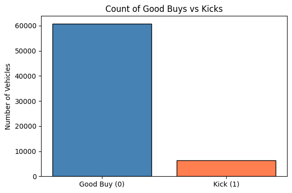

```
Kick rate: 9.55%
```

```python
counts = df['Class'].value_counts().sort_index()
labels = ['Good Buy (0)', 'Kick (1)']

plt.figure(figsize=(6, 4))
plt.bar(labels, counts.values, color=['steelblue', 'coral'], edgecolor='black')
plt.title('Count of Good Buys vs Kicks')
plt.ylabel('Number of Vehicles')
plt.tight_layout()
plt.show()

print(f"Kick rate: {counts[1] / counts.sum() * 100:.2f}%")
```

The data was heavily imbalanced. The vast majority of cars were good buys and only a small fraction were kicks. This makes sense for the real world but it meant a model could just predict good buy every time and still get high accuracy. I kept this in mind when evaluating the models later.

### Chart 2 - Vehicle Age Distribution

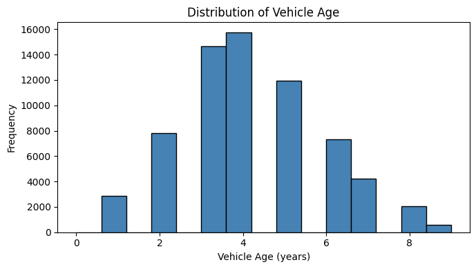

```python
plt.figure(figsize=(7, 4))
plt.hist(df['VehicleAge'].dropna(), bins=15, color='steelblue', edgecolor='black')
plt.title('Distribution of Vehicle Age')
plt.xlabel('Vehicle Age (years)')
plt.ylabel('Frequency')
plt.tight_layout()
plt.show()
```

Most cars at auction were around 3 to 5 years old, which makes sense since that is when leases end and rental fleets turn over.

### Chart 3 - Kick Rate by Vehicle Age

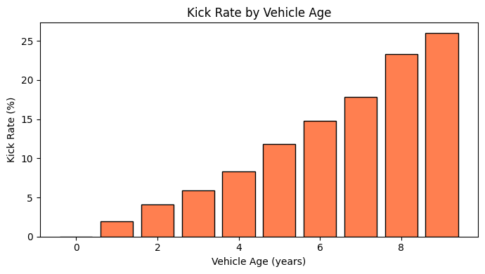

```python
age_kick = df.groupby('VehicleAge')['Class'].mean() * 100

plt.figure(figsize=(7, 4))
plt.bar(age_kick.index, age_kick.values, color='coral', edgecolor='black')
plt.title('Kick Rate by Vehicle Age')
plt.xlabel('Vehicle Age (years)')
plt.ylabel('Kick Rate (%)')
plt.tight_layout()
plt.show()
```

The kick rate generally increased with vehicle age. A 3-year-old car had a lower chance of being a kick compared to a 7 or 8-year-old one. This confirmed that age is a useful predictor.

### Chart 4 - Odometer Distribution

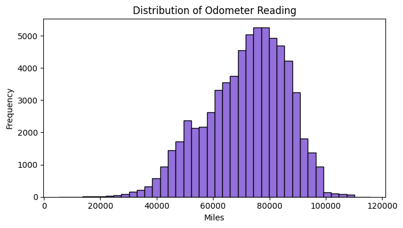

```python
plt.figure(figsize=(7, 4))
plt.hist(df['VehOdo'].dropna(), bins=40, color='mediumpurple', edgecolor='black')
plt.title('Distribution of Odometer Reading')
plt.xlabel('Miles')
plt.ylabel('Frequency')
plt.tight_layout()
plt.show()
```

Odometer readings were clustered around 70,000 to 80,000 miles, which is typical for used auction cars. Higher mileage generally means more wear and tear and a higher chance of problems.

### Chart 5 - Top 10 Makes by Count

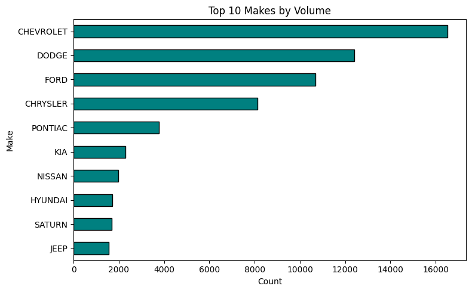

```python
top10 = df['Make'].value_counts().head(10)

plt.figure(figsize=(8, 5))
top10.plot(kind='barh', color='teal', edgecolor='black')
plt.title('Top 10 Makes by Volume')
plt.xlabel('Count')
plt.gca().invert_yaxis()
plt.tight_layout()
plt.show()
```

### Chart 6 - Kick Rate by Auction Provider

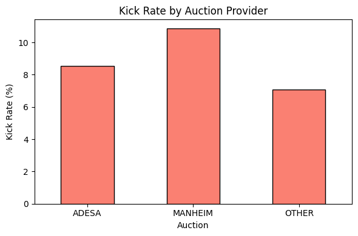

```python
auction_kick = df.groupby('Auction')['Class'].mean() * 100

plt.figure(figsize=(6, 4))
auction_kick.plot(kind='bar', color='salmon', edgecolor='black')
plt.title('Kick Rate by Auction Provider')
plt.ylabel('Kick Rate (%)')
plt.xticks(rotation=0)
plt.tight_layout()
plt.show()
```

There were some differences in kick rates across auction providers. This could reflect different quality standards or the types of vehicles each provider tends to handle. It seemed like a useful variable to include.

### Chart 7 - Kick Rate by Vehicle Size

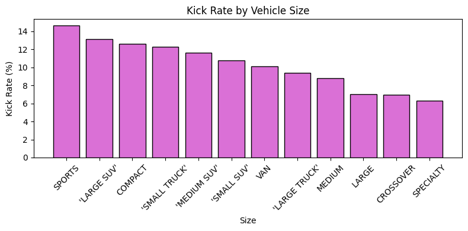

```python
size_kick = df.groupby('Size')['Class'].mean() * 100
size_kick = size_kick.sort_values(ascending=False)

plt.figure(figsize=(8, 4))
plt.bar(size_kick.index, size_kick.values, color='orchid', edgecolor='black')
plt.title('Kick Rate by Vehicle Size')
plt.xlabel('Size')
plt.ylabel('Kick Rate (%)')
plt.xticks(rotation=45)
plt.tight_layout()
plt.show()
```

The kick rate varied quite a bit across size categories. Some sizes had noticeably higher kick rates, which suggested that size is worth keeping as a feature for the model.

### Chart 8 - Acquisition Cost by Class

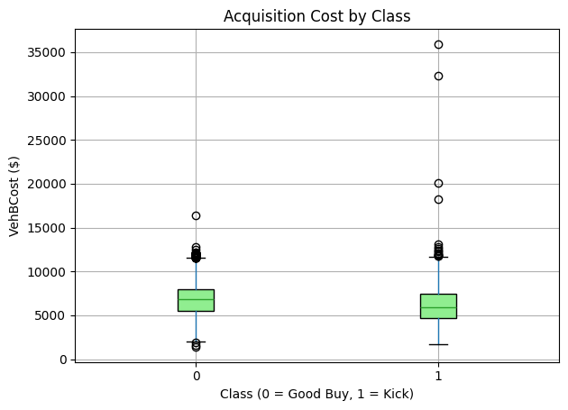

```
Median cost - Good Buys: 6825.0
Median cost - Kicks: 5935.0
```

```python
plt.figure(figsize=(6, 4))
df.boxplot(column='VehBCost', by='Class', patch_artist=True,
           boxprops=dict(facecolor='lightgreen'))
plt.title('Acquisition Cost by Class')
plt.suptitle('')
plt.xlabel('Class (0 = Good Buy, 1 = Kick)')
plt.ylabel('VehBCost ($)')
plt.tight_layout()
plt.show()

print(f"Median cost - Good Buys: {df.loc[df['Class']==0, 'VehBCost'].median()}")
print(f"Median cost - Kicks: {df.loc[df['Class']==1, 'VehBCost'].median()}")
```

Kicked cars tended to be cheaper on average. This makes sense because riskier, more problematic cars are usually the ones nobody wants to pay much for. The lower price could be a signal that something is off with the vehicle.

### Chart 9 - Warranty Cost by Class

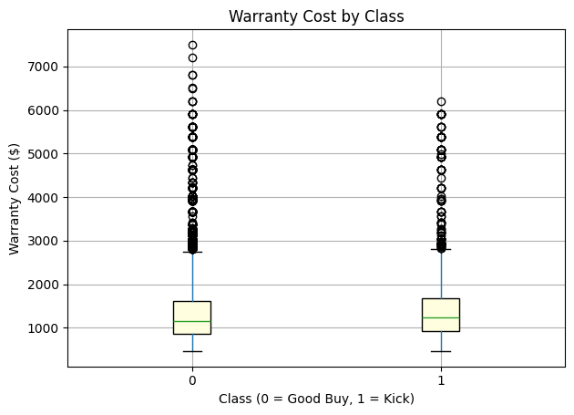

```python
plt.figure(figsize=(6, 4))
df.boxplot(column='WarrantyCost', by='Class', patch_artist=True,
           boxprops=dict(facecolor='lightyellow'))
plt.title('Warranty Cost by Class')
plt.suptitle('')
plt.xlabel('Class (0 = Good Buy, 1 = Kick)')
plt.ylabel('Warranty Cost ($)')
plt.tight_layout()
plt.show()
```

Kicked cars tended to have slightly higher warranty costs. This might be because warranty providers recognize riskier vehicles and charge more, or because the types of cars that get kicked happen to be ones with more expensive warranties.

### Chart 10 - Correlation Heatmap

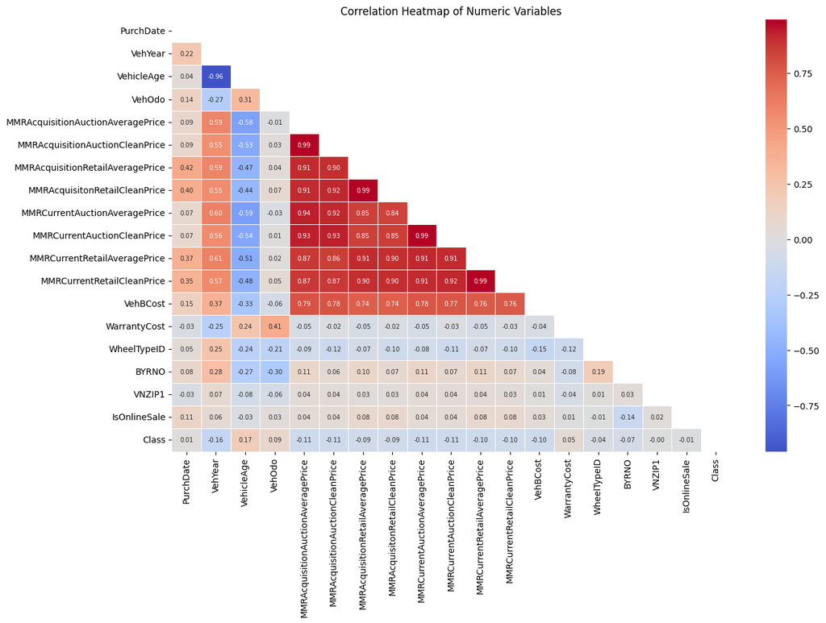

```python
numeric_cols = df.select_dtypes(include=[np.number]).columns.tolist()
corr = df[numeric_cols].corr()

plt.figure(figsize=(14, 10))
mask = np.triu(np.ones_like(corr, dtype=bool))
sns.heatmap(corr, mask=mask, annot=True, fmt='.2f', cmap='coolwarm',
            center=0, linewidths=0.5, annot_kws={'size': 7})
plt.title('Correlation Heatmap of Numeric Variables')
plt.tight_layout()
plt.show()
```

### Target Variable and Predictors

The target variable is Class. It is a binary categorical variable where 0 means good buy and 1 means kick.

## Data Preparation

I needed to clean the data before feeding it into a model. I dropped unnecessary columns, fixed data types, handled missing values and outliers, removed redundant correlated columns, and encoded the categorical variables.

### Dropping Unnecessary Columns

```python
drop_cols = ['PurchDate', 'Model', 'Trim', 'SubModel',
             'BYRNO', 'VNZIP1', 'VehYear']

df_clean = df.drop(columns=drop_cols, errors='ignore')
print(f"Columns remaining: {df_clean.shape[1]}")
print(list(df_clean.columns))
```

[output not shown]

### Fixing Variable Types

```python
df_clean['WheelTypeID'] = df_clean['WheelTypeID'].astype('object')
df_clean['IsOnlineSale'] = df_clean['IsOnlineSale'].astype('object')

print(df_clean.dtypes)
```

```
VehicleAge                             int64
VehOdo                               float64
MMRAcquisitionAuctionAveragePrice    float64
MMRAcquisitionAuctionCleanPrice      float64
MMRAcquisitionRetailAveragePrice     float64
MMRAcquisitonRetailCleanPrice        float64
MMRCurrentAuctionAveragePrice        float64
MMRCurrentAuctionCleanPrice          float64
MMRCurrentRetailAveragePrice         float64
MMRCurrentRetailCleanPrice           float64
VehBCost                             float64
WarrantyCost                         float64
Auction                               object
Make                                  object
Color                                 object
Transmission                          object
WheelTypeID                           object
WheelType                             object
Nationality                           object
Size                                  object
TopThreeAmericanName                  object
VNST                                  object
IsOnlineSale                          object
Class                                  int64
dtype: object
```

I converted WheelTypeID and IsOnlineSale to object type. WheelTypeID is just a code (1, 2, 3) and IsOnlineSale is 0 or 1 for yes/no. They are not numbers you would do math with, so treating them as categories ensures they get dummy-coded properly later.

### Handling Missing Values

```python
missing = df_clean.isnull().sum()
missing_pct = (missing / len(df_clean) * 100).round(2)
missing_summary = pd.DataFrame({'Count': missing, '%': missing_pct})
print(missing_summary[missing_summary['Count'] > 0].sort_values('%', ascending=False))

numeric_features = df_clean.select_dtypes(include=[np.number]).columns.tolist()
numeric_features = [c for c in numeric_features if c != 'Class']
categorical_features = df_clean.select_dtypes(include=['object']).columns.tolist()

for col in numeric_features:
    if df_clean[col].isnull().sum() > 0:
        median_val = df_clean[col].median()
        df_clean[col].fillna(median_val, inplace=True)

for col in categorical_features:
    if df_clean[col].isnull().sum() > 0:
        mode_val = df_clean[col].mode()[0]
        df_clean[col].fillna(mode_val, inplace=True)

print(f"\nRemaining missing values: {df_clean.isnull().sum().sum()}")
```

```
Empty DataFrame
Columns: [Count, %]
Index: []

Remaining missing values: 0
```

There were no missing values to fill in this dataset. The code was set up to fill numeric columns with the median and categorical columns with the mode in case there were any, but since everything was already complete it did not change anything.

### Handling Outliers

```python
outlier_cols = ['VehOdo', 'VehBCost', 'WarrantyCost',
                'MMRAcquisitionAuctionAveragePrice', 'MMRAcquisitionAuctionCleanPrice',
                'MMRAcquisitionRetailAveragePrice', 'MMRAcquisitonRetailCleanPrice',
                'MMRCurrentAuctionAveragePrice', 'MMRCurrentAuctionCleanPrice',
                'MMRCurrentRetailAveragePrice', 'MMRCurrentRetailCleanPrice']

for col in outlier_cols:
    if col not in df_clean.columns:
        continue
    Q1 = df_clean[col].quantile(0.25)
    Q3 = df_clean[col].quantile(0.75)
    IQR = Q3 - Q1
    lower = Q1 - 1.5 * IQR
    upper = Q3 + 1.5 * IQR
    n_outliers = ((df_clean[col] < lower) | (df_clean[col] > upper)).sum()
    if n_outliers > 0:
        df_clean[col] = df_clean[col].clip(lower=lower, upper=upper)
        print(f"{col}: capped {n_outliers} outliers to [{lower:.0f}, {upper:.0f}]")

print("\nDone.")
```

```
VehOdo: capped 282 outliers to [31612, 113080]
VehBCost: capped 169 outliers to [1810, 11570]
WarrantyCost: capped 696 outliers to [-302, 2778]
MMRAcquisitionAuctionAveragePrice: capped 450 outliers to [-932, 13048]
MMRAcquisitionAuctionCleanPrice: capped 1543 outliers to [68, 14438]
MMRAcquisitionRetailAveragePrice: capped 261 outliers to [-267, 17295]
MMRAcquisitonRetailCleanPrice: capped 1131 outliers to [584, 19096]
MMRCurrentAuctionAveragePrice: capped 502 outliers to [-886, 12974]
MMRCurrentAuctionCleanPrice: capped 1233 outliers to [102, 14410]
MMRCurrentRetailAveragePrice: capped 233 outliers to [-46, 17582]
MMRCurrentRetailCleanPrice: capped 829 outliers to [1000, 19192]

Done.
```

Instead of deleting rows with outliers, I used the IQR method to cap extreme values. Anything more than 1.5 times the IQR below Q1 or above Q3 got clipped to the boundary. This keeps all the rows but prevents extreme values from distorting the model.

### Removing Correlated Columns

```python
mmr_drop = ['MMRAcquisitionAuctionCleanPrice',
            'MMRAcquisitionRetailAveragePrice',
            'MMRAcquisitonRetailCleanPrice',
            'MMRCurrentAuctionAveragePrice',
            'MMRCurrentAuctionCleanPrice',
            'MMRCurrentRetailCleanPrice']

df_clean.drop(columns=mmr_drop, inplace=True, errors='ignore')
print(f"Columns remaining: {df_clean.shape[1]}")
print(list(df_clean.columns))
```

```
Columns remaining: 18
['VehicleAge', 'VehOdo', 'MMRAcquisitionAuctionAveragePrice', 'MMRCurrentRetailAveragePrice', 'VehBCost', 'WarrantyCost', 'Auction', 'Make', 'Color', 'Transmission', 'WheelTypeID', 'WheelType', 'Nationality', 'Size', 'TopThreeAmericanName', 'VNST', 'IsOnlineSale', 'Class']
```

### Class Balance

```python
balance = df_clean['Class'].value_counts().sort_index()
print("Class distribution:")
print(balance)
print(f"\nKick rate: {balance[1] / balance.sum() * 100:.2f}%")
print(f"Imbalance ratio: {balance[0] / balance[1]:.1f} : 1")
```

```
Class distribution:
Class
0    60795
1     6416
Name: count, dtype: int64

Kick rate: 9.55%
Imbalance ratio: 9.5 : 1
```

The data was not balanced. Good buys outnumbered kicks by about 9.5 to 1. This is common in problems like fraud detection or defect prediction where the bad cases are always the minority. There are techniques to address this like SMOTE (creating synthetic minority samples), random oversampling, random undersampling, or using class weights in the model. I did not apply any of these for this assignment but they could improve performance in the future.

### Dummy Coding

```python
cat_cols = df_clean.select_dtypes(include=['object']).columns.tolist()
print(f"Categorical columns to encode: {len(cat_cols)}")
for c in cat_cols:
    print(f"  {c}: {df_clean[c].nunique()} unique values")

df_model = pd.get_dummies(df_clean, columns=cat_cols, drop_first=True)
print(f"\nFinal dataset shape: {df_model.shape}")
```

```
Categorical columns to encode: 11
  Auction: 3 unique values
  Make: 32 unique values
  Color: 16 unique values
  Transmission: 3 unique values
  WheelTypeID: 3 unique values
  WheelType: 3 unique values
  Nationality: 4 unique values
  Size: 12 unique values
  TopThreeAmericanName: 4 unique values
  VNST: 37 unique values
  IsOnlineSale: 2 unique values

Final dataset shape: (67211, 115)
```

I used one-hot encoding with drop_first=True to convert categorical columns into binary columns. The drop_first parameter drops one category from each group to avoid the dummy variable trap where one column would be perfectly predictable from the others.

## Modeling

I built decision trees with different depth limits to find the best balance between underfitting and overfitting. A very shallow tree might be too simple while a very deep tree might memorize the training data.

### Train/Test Split

```python
X = df_model.drop(columns=['Class'])
y = df_model['Class']

X_train, X_test, y_train, y_test = train_test_split(
    X, y, test_size=0.30, random_state=42, stratify=y
)

print(f"Training set: {X_train.shape[0]} samples")
print(f"Test set: {X_test.shape[0]} samples")
print(f"Train kick rate: {y_train.mean()*100:.2f}%")
print(f"Test kick rate: {y_test.mean()*100:.2f}%")
```

```
Training set: 47047 samples
Test set: 20164 samples
Train kick rate: 9.55%
Test kick rate: 9.55%
```

I split the data 70/30 with stratify=y to make sure both sets have the same proportion of kicks.

### Model 1 - No Depth Limit

```python
dt_full = DecisionTreeClassifier(random_state=42)
dt_full.fit(X_train, y_train)
y_pred_full = dt_full.predict(X_test)

print(f"Tree depth: {dt_full.get_depth()}")
print(f"Number of leaves: {dt_full.get_n_leaves()}")
print()
print(classification_report(y_test, y_pred_full, target_names=['Good Buy', 'Kick']))
print(f"Accuracy: {accuracy_score(y_test, y_pred_full):.4f}")
print(f"Precision: {precision_score(y_test, y_pred_full):.4f}")
print(f"Recall: {recall_score(y_test, y_pred_full):.4f}")
print(f"F1-Score: {f1_score(y_test, y_pred_full):.4f}")
```

```
Tree depth: 50
Number of leaves: 5579

              precision    recall  f1-score   support

    Good Buy       0.91      0.90      0.90     18239
        Kick       0.14      0.16      0.15      1925

    accuracy                           0.83     20164
   macro avg       0.52      0.53      0.52     20164
weighted avg       0.84      0.83      0.83     20164

Accuracy: 0.8261
Precision: 0.1372
Recall: 0.1553
F1-Score: 0.1457
```

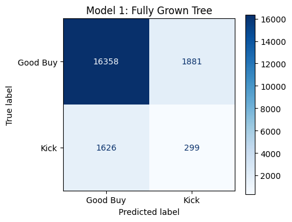

```python
fig, ax = plt.subplots(figsize=(5, 4))
ConfusionMatrixDisplay.from_predictions(y_test, y_pred_full,
    display_labels=['Good Buy', 'Kick'], cmap='Blues', ax=ax)
ax.set_title('Model 1: Fully Grown Tree')
plt.tight_layout()
plt.show()
```

This was a fully grown tree with no depth restriction. It went very deep and had a lot of leaves, which means it was probably overfitting by memorizing the training data including noise. The confusion matrix showed the breakdown of correct and incorrect predictions.

### Model 2 - max_depth = 3

```python
dt_d3 = DecisionTreeClassifier(max_depth=3, random_state=42)
dt_d3.fit(X_train, y_train)
y_pred_d3 = dt_d3.predict(X_test)

print(f"Tree depth: {dt_d3.get_depth()}")
print(f"Number of leaves: {dt_d3.get_n_leaves()}")
print()
print(classification_report(y_test, y_pred_d3, target_names=['Good Buy', 'Kick']))
print(f"Accuracy: {accuracy_score(y_test, y_pred_d3):.4f}")
print(f"Precision: {precision_score(y_test, y_pred_d3):.4f}")
print(f"Recall: {recall_score(y_test, y_pred_d3):.4f}")
print(f"F1-Score: {f1_score(y_test, y_pred_d3):.4f}")
```

```
Tree depth: 3
Number of leaves: 8

              precision    recall  f1-score   support

    Good Buy       0.90      1.00      0.95     18239
        Kick       0.00      0.00      0.00      1925

    accuracy                           0.90     20164
   macro avg       0.45      0.50      0.47     20164
weighted avg       0.82      0.90      0.86     20164

Accuracy: 0.9045
Precision: 0.0000
Recall: 0.0000
F1-Score: 0.0000
```

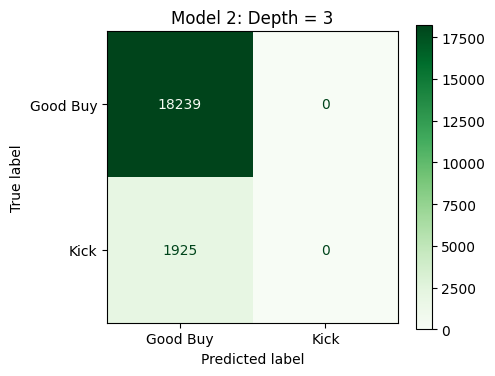

```python
fig, ax = plt.subplots(figsize=(5, 4))
ConfusionMatrixDisplay.from_predictions(y_test, y_pred_d3,
    display_labels=['Good Buy', 'Kick'], cmap='Greens', ax=ax)
ax.set_title('Model 2: Depth = 3')
plt.tight_layout()
plt.show()
```

With only 3 levels this tree was very simple. It had high accuracy but it did not predict a single kick. It was just predicting good buy for every car and getting credit for the roughly 90% of cases that really are good buys.

### Model 3 - max_depth = 5

```python
dt_d5 = DecisionTreeClassifier(max_depth=5, random_state=42)
dt_d5.fit(X_train, y_train)
y_pred_d5 = dt_d5.predict(X_test)

print(f"Tree depth: {dt_d5.get_depth()}")
print(f"Number of leaves: {dt_d5.get_n_leaves()}")
print()
print(classification_report(y_test, y_pred_d5, target_names=['Good Buy', 'Kick']))
print(f"Accuracy: {accuracy_score(y_test, y_pred_d5):.4f}")
print(f"Precision: {precision_score(y_test, y_pred_d5):.4f}")
print(f"Recall: {recall_score(y_test, y_pred_d5):.4f}")
print(f"F1-Score: {f1_score(y_test, y_pred_d5):.4f}")
```

```
Tree depth: 5
Number of leaves: 31

              precision    recall  f1-score   support

    Good Buy       0.90      1.00      0.95     18239
        Kick       0.29      0.00      0.00      1925

    accuracy                           0.90     20164
   macro avg       0.60      0.50      0.48     20164
weighted avg       0.85      0.90      0.86     20164

Accuracy: 0.9044
Precision: 0.2857
Recall: 0.0010
F1-Score: 0.0021
```

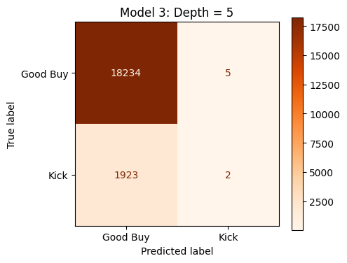

```python
fig, ax = plt.subplots(figsize=(5, 4))
ConfusionMatrixDisplay.from_predictions(y_test, y_pred_d5,
    display_labels=['Good Buy', 'Kick'], cmap='Oranges', ax=ax)
ax.set_title('Model 3: Depth = 5')
plt.tight_layout()
plt.show()
```

Depth 5 gave the tree more room to learn patterns but it still barely caught any kicks. The recall was nearly zero, meaning it only flagged a couple of kicks out of nearly 2,000. It was still mostly just predicting good buy for everything.

### Model 4 - max_depth = 7

```python
dt_d7 = DecisionTreeClassifier(max_depth=7, random_state=42)
dt_d7.fit(X_train, y_train)
y_pred_d7 = dt_d7.predict(X_test)

print(f"Tree depth: {dt_d7.get_depth()}")
print(f"Number of leaves: {dt_d7.get_n_leaves()}")
print()
print(classification_report(y_test, y_pred_d7, target_names=['Good Buy', 'Kick']))
print(f"Accuracy: {accuracy_score(y_test, y_pred_d7):.4f}")
print(f"Precision: {precision_score(y_test, y_pred_d7):.4f}")
print(f"Recall: {recall_score(y_test, y_pred_d7):.4f}")
print(f"F1-Score: {f1_score(y_test, y_pred_d7):.4f}")
```

```
Tree depth: 7
Number of leaves: 103

              precision    recall  f1-score   support

    Good Buy       0.90      1.00      0.95     18239
        Kick       0.13      0.00      0.01      1925

    accuracy                           0.90     20164
   macro avg       0.52      0.50      0.48     20164
weighted avg       0.83      0.90      0.86     20164

Accuracy: 0.9021
Precision: 0.1343
Recall: 0.0047
F1-Score: 0.0090
```

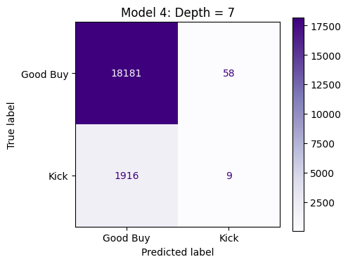

```python
fig, ax = plt.subplots(figsize=(5, 4))
ConfusionMatrixDisplay.from_predictions(y_test, y_pred_d7,
    display_labels=['Good Buy', 'Kick'], cmap='Purples', ax=ax)
ax.set_title('Model 4: Depth = 7')
plt.tight_layout()
plt.show()
```

Depth 7 caught a few more kicks than the shallower trees but still only 9 out of nearly 2,000. The recall was still close to zero. The extra depth did not help much with the core problem of detecting kicks.

### Model 5 - max_depth = 10

```python
dt_d10 = DecisionTreeClassifier(max_depth=10, random_state=42)
dt_d10.fit(X_train, y_train)
y_pred_d10 = dt_d10.predict(X_test)

print(f"Tree depth: {dt_d10.get_depth()}")
print(f"Number of leaves: {dt_d10.get_n_leaves()}")
print()
print(classification_report(y_test, y_pred_d10, target_names=['Good Buy', 'Kick']))
print(f"Accuracy: {accuracy_score(y_test, y_pred_d10):.4f}")
print(f"Precision: {precision_score(y_test, y_pred_d10):.4f}")
print(f"Recall: {recall_score(y_test, y_pred_d10):.4f}")
print(f"F1-Score: {f1_score(y_test, y_pred_d10):.4f}")
```

```
Tree depth: 10
Number of leaves: 385

              precision    recall  f1-score   support

    Good Buy       0.91      0.99      0.95     18239
        Kick       0.19      0.02      0.04      1925

    accuracy                           0.90     20164
   macro avg       0.55      0.51      0.49     20164
weighted avg       0.84      0.90      0.86     20164

Accuracy: 0.8983
Precision: 0.1891
Recall: 0.0197
F1-Score: 0.0357
```

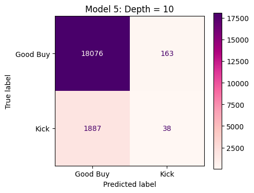

```python
fig, ax = plt.subplots(figsize=(5, 4))
ConfusionMatrixDisplay.from_predictions(y_test, y_pred_d10,
    display_labels=['Good Buy', 'Kick'], cmap='RdPu', ax=ax)
ax.set_title('Model 5: Depth = 10')
plt.tight_layout()
plt.show()
```

### Comparing All Models

```python
models = {
    'Full Tree (no limit)': (dt_full, y_pred_full),
    'Depth = 3': (dt_d3, y_pred_d3),
    'Depth = 5': (dt_d5, y_pred_d5),
    'Depth = 7': (dt_d7, y_pred_d7),
    'Depth = 10': (dt_d10, y_pred_d10),
}

results = []
for name, (model, preds) in models.items():
    results.append({
        'Model': name,
        'Depth': model.get_depth(),
        'Leaves': model.get_n_leaves(),
        'Accuracy': accuracy_score(y_test, preds),
        'Precision (Kick)': precision_score(y_test, preds),
        'Recall (Kick)': recall_score(y_test, preds),
        'F1 (Kick)': f1_score(y_test, preds),
    })

results_df = pd.DataFrame(results).round(4)
print(results_df.to_string(index=False))
```

```
               Model  Depth  Leaves  Accuracy  Precision (Kick)  Recall (Kick)  F1 (Kick)
Full Tree (no limit)     50    5579    0.8261            0.1372         0.1553     0.1457
           Depth = 3      3       8    0.9045            0.0000         0.0000     0.0000
           Depth = 5      5      31    0.9044            0.2857         0.0010     0.0021
           Depth = 7      7     103    0.9021            0.1343         0.0047     0.0090
          Depth = 10     10     385    0.8983            0.1891         0.0197     0.0357
```

Accuracy looked high for all models but that was partly because of the class imbalance. The more useful metrics were precision, recall, and F1 for kicks. Precision told me how often the model was right when it flagged a kick. Recall told me what fraction of actual kicks the model caught. F1 balanced both. The shallow and mid-range trees had high accuracy but almost zero recall because they barely flagged any kicks at all. The fully grown tree was the only one with meaningful recall and F1 for kicks, even though it was likely overfitting. Overall the results showed that a basic decision tree struggles with this imbalanced dataset. I picked the model with the best F1-score for kicks as the winner, which was the fully grown tree.

### Feature Importance

```
Best model: Full Tree (no limit) (F1 for Kick = 0.1457)
```

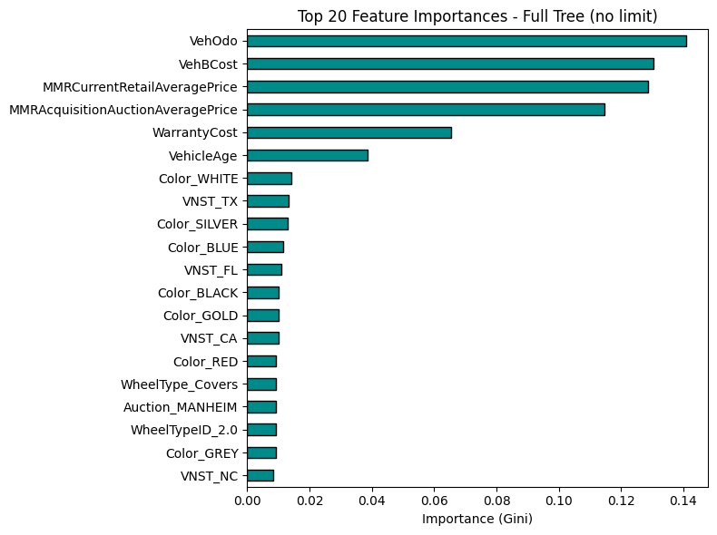

```python
best_idx = results_df['F1 (Kick)'].idxmax()
best_name = results_df.loc[best_idx, 'Model']
print(f"Best model: {best_name} (F1 for Kick = {results_df.loc[best_idx, 'F1 (Kick)']:.4f})")

best_models_dict = {
    'Full Tree (no limit)': dt_full,
    'Depth = 3': dt_d3,
    'Depth = 5': dt_d5,
    'Depth = 7': dt_d7,
    'Depth = 10': dt_d10,
}
best_model = best_models_dict[best_name]

importances = pd.Series(best_model.feature_importances_, index=X.columns)
top20 = importances.nlargest(20)

plt.figure(figsize=(8, 6))
top20.sort_values().plot(kind='barh', color='darkcyan', edgecolor='black')
plt.title(f'Top 20 Feature Importances - {best_name}')
plt.xlabel('Importance (Gini)')
plt.tight_layout()
plt.show()
```

The top features were mostly pricing-related (MMR values, acquisition cost) along with vehicle age and odometer reading. This lined up with what I found during the charts where cheaper, older, and higher-mileage cars were riskier. Warranty cost also showed up, which makes sense because pricier warranties often reflect higher perceived risk.

### Tree Visualization

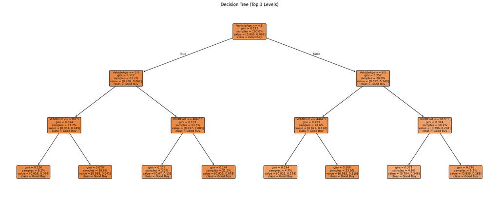

```python
viz_model = dt_d3 if best_model.get_depth() > 5 else best_model

plt.figure(figsize=(20, 8))
plot_tree(viz_model, max_depth=3, filled=True, rounded=True,
          feature_names=X.columns, class_names=['Good Buy', 'Kick'],
          fontsize=8, proportion=True)
plt.title('Decision Tree (Top 3 Levels)')
plt.tight_layout()
plt.show()
```

This showed how the tree makes its decisions. Each node splits on a feature at a threshold value and the color shows the majority class at that point. You can trace any path from root to leaf to understand why the model classified a car a certain way. This transparency is one of the main advantages of decision trees over black-box models.

## Evaluation

The model I selected was the fully grown tree since it had the best F1-score for predicting kicks, though the performance was still low overall with an F1 of about 0.15 and recall of about 0.16. That means it only caught around 15% of actual kicks. Going back to the original business problem, dealers lose money on cars that turn out to have hidden issues. Even with its limitations, this model could serve as a starting point for a risk screening tool at auction time, but it would need significant improvement before being reliable.

In terms of practicality, decision trees are easy to explain to people who are not data scientists. You can show them the tree and walk through the logic. Predictions are also instant once the model is trained, which matters at auctions where decisions happen fast. The feature importance analysis also tells the business which factors matter most, which is useful even beyond the predictions.

The main limitations are the class imbalance, which makes it hard to catch all kicks without also flagging too many good buys, and the fact that a single decision tree can be unstable where small changes in data produce a different tree. For a production system, I would recommend trying ensemble methods like Random Forest, addressing the class imbalance with SMOTE or class weights, and doing a more thorough hyperparameter search.

```python
!jupyter nbconvert --to html "/content/drive/MyDrive/Colab Notebooks/Assignment1_Car.ipynb" --output NikumbhMehul --output-dir /content/
from google.colab import files
files.download("/content/NikumbhMehul.html")
```

```
[NbConvertApp] Converting notebook /content/drive/MyDrive/Colab Notebooks/Assignment1_Car.ipynb to html
[NbConvertApp] WARNING | Alternative text is missing on 17 image(s).
[NbConvertApp] Writing 1391110 bytes to /content/NikumbhMehul.html
```